# Selección de Variables Datos Vino

## Preliminares

En este documento se presentan varias alternativas para las selección automática de variables en modelos de regresión. Esta técnicas automáticas resulta útiles cuando nos enfrentamos a gran cantidad de variables y esto hace que el proceso manual sea difícil de abordar. En cualquier caso, hemos de saber que no son mágicas y que tienen sus debilidades, por lo que el control de las mismas por nuestra parte se hace fundamental de cara a la obtención de buenos resultados en su aplicación.

En primer lugar se fija el directorio de trabajo donde tenemos las funciones y los datos.

Procedemos a la lectura de los datos depurados y con las transformaciones creadas en el código de regresión lineal.

```r
# Parto de los datos con las transformaciones creado en el código de regresión lineal
datos<-readRDS("F:/Documentos/Master Comercio 2021-22/Online_Material Minería de Datos_Otoño2021/Dia2_Regresion Lineal/todo_cont_Vino.RDS")
```

## Modelo manual ganador

Rescatamos el modelo ganador en nuestro proceso de ajuste manual de modelos de regresión lineal.

Debido a que habíamos considerado una tramificaión de Azucar por árboles y no guardamos el factor correspondiente en el input. Lo volvemos a generar.

**Nota**: Es posible que se produzcan variaciones en pasos como este de tramificación e incluso en los modelos cuando ejecutamos todos los códigos desde el primero de depuración de los datos. La razón es la aleatoriedad en la imputación de los datos (recordamos que utilizábamos la opción aleatorio para no subestimar mucho la varianza). Esto produce que el valor de las imputaciones pueda cambiar con cada ejecución de aquel código, con lo que los registros varían ligeramente haciéndolo así mismo los patrones que puedan generar. Cuando las variaciones son pequeñas, no hay problema. Si en algún momento observáramos grandes diferencias habría que replantear las imputaciones.

```r
# Arbol para tramificar azucar
tree_azucar<-rpart::rpart(varObjCont~Azucar, data = datos, cp=0.005)
tree_azucar
```

```
## n= 6365
##
## node), split, n, deviance, yval
##       * denotes terminal node
##
## 1) root 6365 605207200 452.3802
##   2) Azucar< 4.48975 3222 323203600 435.1741
##     4) Azucar>=1.6474 969 110011800 372.0000 *
##     5) Azucar< 1.6474 2253 207661200 462.3449 *
##   3) Azucar>=4.48975 3143 280071900 470.0188 *
```

```r
# puntos de corte en 1.64 y 4.58. Tres grupos.
table(tree_azucar$where)
```

```
##
##    3    4    5
##  969 2253 3143
```

```r
# Los grupos están ya ordenados pero se llaman 3 4 y 5

# Añadimos la variable tramificada al dataset
datos$Azucar_tree<-factor(tree_azucar$where)

# Cambiamos los niveles
levels(datos$Azucar_tree) = c('<1.64','1.64-4.58','>4.58')

# Comprobamos
table(datos$Azucar_tree)
```

```
##
##     <1.64 1.64-4.58     >4.58
##       969      2253      3143
```

Tomamos la partición para implementar nuestro esquema training/test.

```r
#Hago la partición
set.seed(123456)
trainIndex <- createDataPartition(datos$varObjCont, p=0.8, list=FALSE)
data_train <- datos[trainIndex,]
data_test <- datos[-trainIndex,]
```

El modelo ganador contenía las variables *Clasificacion*, *Etiqueta*, *CalifProd_cont* y *Azucar_tree*.

```r
# Este fue el modelo manual ganador
modeloManual<-lm(varObjCont~Clasificacion+Etiqueta+CalifProd_cont+Azucar_tree,data=data_train)
summary(modeloManual)
```

```
##
## Call:
## lm(formula = varObjCont ~ Clasificacion + Etiqueta + CalifProd_cont +
##     Azucar_tree, data = data_train)
##
## Residuals:
##     Min      1Q  Median      3Q     Max
## -684.64 -163.21  -16.87  148.65  966.47
##
## Coefficients:
##                          Estimate Std. Error t value Pr(>|t|)
## (Intercept)               534.192     14.327  37.286  < 2e-16 ***
## Clasificacion**           142.221      8.845  16.080  < 2e-16 ***
## Clasificacion***          242.519     10.276  23.600  < 2e-16 ***
## Clasificacion****         336.825     16.189  20.806  < 2e-16 ***
## ClasificacionDesconocido -215.491      8.952 -24.071  < 2e-16 ***
## EtiquetaM                -137.108      9.375 -14.626  < 2e-16 ***
## EtiquetaMB                 61.702     17.463   3.533 0.000414 ***
## EtiquetaMM               -207.840     17.372 -11.964  < 2e-16 ***
## EtiquetaR                 -73.990      8.157  -9.071  < 2e-16 ***
## CalifProd_cont            -30.801      2.445 -12.598  < 2e-16 ***
## Azucar_tree1.64-4.58       38.929      9.729   4.001 6.39e-05 ***
## Azucar_tree>4.58           43.218      9.290   4.652 3.37e-06 ***
## ---
## Signif. codes:  0 '***' 0.001 '**' 0.01 '*' 0.05 '.' 0.1 ' ' 1
##
## Residual standard error: 224.4 on 5082 degrees of freedom
## Multiple R-squared:  0.472,  Adjusted R-squared:  0.4709
## F-statistic: 413.1 on 11 and 5082 DF,  p-value: < 2.2e-16
```

```r
Rsq(modeloManual,"varObjCont",data_train)
```

```
## $r2
## [1] 0.4720457
##
## $r2_adj
## [1] 0.4707988
```

```r
Rsq(modeloManual,"varObjCont",data_test)
```

```
## $r2
## [1] 0.4867726
##
## $r2_adj
## [1] 0.4818769
```

El objetivo es, por tanto, valorar si la selección de variables automática en alguna de sus variantes puede ayudar a mejorar la capacidad predictiva del modelo sin aumentar muchísimo la complejidad.

Abordamos la selección de variables “clasica” mediante la función *step()* de R. El objetivo de esta función es proponer un subconjunto de variables que considera óptimo en relación a una determinada métrica (Criterio de Akaike o Criterio de Información Bayesiana/Criterio de Schwarz) de entre todas las disponibles.

Nuestro plan es variar tanto la métrica como las variables o efectos disponibles. De esta forma haremos pruebas con los distintos criterios para conjuntos de variables con complejidad creciente.

1. Variables originales
2. Variables originales + interacciones
3. Variables originales + transformaciones
4. Variables originales + interacciones + transformaciones

## Selección de variables clásica con variables originales

La función *step()* tiene 3 formas de proceder:

1. Hacia delante (forward): Partiendo del modelo nulo (solo con la constante), introduce uno a uno los efectos desde el más importante en cuanto a su aportación al R2 (verosimilitud en caso de regresión logística). Cuando un efecto entra, ya no puede salir.
2. Hacia atrás (backward): Partiendo del modelo completo (todas las variables), elimina uno a uno los efectos desde el menos importante en cuanto a su aportación al R2 (verosimilitud en caso de regresión logística). Cuando un efecto sale, ya no puede entrar.
3. Por pasos (Stepwise/ both en step()): Realiza el forward pero valorando el efecto de la salida de variables que ya fueron incluidas en modelo. Las variables pueden entrar y volver a salir del modelo (pueden darse efectos de confusión entre variables)

Para implementar esta técnica necesitamos:

- un modelo null
- un modelo full (aquí es donde se controlan el número de efectos disponibles)
- dirección de proceso de entre las 3 anteriores
- métrica para la función objetivo del algoritmo: AIC (menor penalización de número d parámetros –> tendencia a modelo más complejos) ó BIC/SBC (mayor penalización de número d parámetros –> tendencia a modelos más simples)

Vamos a probar con ambas métricas y dirección step y backward –> 4 modelos.

```r
# Seleccion de variables "clásica"
null<-lm(varObjCont~1, data=data_train) #Modelo minimo
full<-lm(varObjCont~.-ID, data=data_train[,c(1:18,33,34)]) #Modelo maximo, le quitamos las transformaciones

modeloStepAIC<-step(null, scope=list(lower=null, upper=full), direction="both", trace = F)
summary(modeloStepAIC)
```

```
##
## Call:
## lm(formula = varObjCont ~ Clasificacion + Etiqueta + CalifProd_cont +
##     Azucar_tree + Acidez + CalifProductor + CloruroSodico + Alcohol +
##     pH, data = data_train)
##
## Residuals:
##     Min      1Q  Median      3Q     Max
## -691.54 -161.16  -16.84  147.59  977.75
##
## Coefficients:
##                           Estimate Std. Error t value Pr(>|t|)
## (Intercept)               530.0429    26.5923  19.932  < 2e-16 ***
## Clasificacion**           140.8540     8.8165  15.976  < 2e-16 ***
## Clasificacion***          238.9902    10.2682  23.275  < 2e-16 ***
## Clasificacion****         333.2875    16.1523  20.634  < 2e-16 ***
## ClasificacionDesconocido -213.3703     8.9362 -23.877  < 2e-16 ***
## EtiquetaM                -138.2843     9.3473 -14.794  < 2e-16 ***
## EtiquetaMB                 59.2664    17.4184   3.403 0.000673 ***
## EtiquetaMM               -210.5430    17.3338 -12.146  < 2e-16 ***
## EtiquetaR                 -76.0356     8.1431  -9.337  < 2e-16 ***
## CalifProd_cont            -30.0581     8.2664  -3.636 0.000279 ***
## Azucar_tree1.64-4.58       36.6489     9.7074   3.775 0.000162 ***
## Azucar_tree>4.58           39.7808     9.2874   4.283 1.88e-05 ***
## Acidez                    -16.3097     4.4321  -3.680 0.000236 ***
## CalifProductor2            12.1344    14.0021   0.867 0.386197
## CalifProductor3            31.3754    20.3134   1.545 0.122514
## CalifProductor4            11.4727    28.6556   0.400 0.688905
## CalifProductor5-12         -6.3461    43.9084  -0.145 0.885087
## CloruroSodico             -28.4777    10.7081  -2.659 0.007851 **
## Alcohol                     2.3452     0.9069   2.586 0.009743 **
## pH                         -8.4611     5.1493  -1.643 0.100413
## ---
## Signif. codes:  0 '***' 0.001 '**' 0.01 '*' 0.05 '.' 0.1 ' ' 1
##
## Residual standard error: 223.6 on 5074 degrees of freedom
## Multiple R-squared:  0.4768, Adjusted R-squared:  0.4748
## F-statistic: 243.3 on 19 and 5074 DF,  p-value: < 2.2e-16
```

```r
Rsq(modeloStepAIC,"varObjCont",data_test)
```

```
## $r2
## [1] 0.4870955
##
## $r2_adj
## [1] 0.478889
```

```r
modeloBackAIC<-step(full, scope=list(lower=null, upper=full), direction="backward", trace = F)
summary(modeloBackAIC)
```

```
##
## Call:
## lm(formula = varObjCont ~ Acidez + CloruroSodico + pH + Alcohol +
##     Etiqueta + CalifProductor + Clasificacion + CalifProd_cont +
##     Azucar_tree, data = data_train[, c(1:18, 33, 34)])
##
## Residuals:
##     Min      1Q  Median      3Q     Max
## -691.54 -161.16  -16.84  147.59  977.75
##
## Coefficients:
##                           Estimate Std. Error t value Pr(>|t|)
## (Intercept)               530.0429    26.5923  19.932  < 2e-16 ***
## Acidez                    -16.3097     4.4321  -3.680 0.000236 ***
## CloruroSodico             -28.4777    10.7081  -2.659 0.007851 **
## pH                         -8.4611     5.1493  -1.643 0.100413
## Alcohol                     2.3452     0.9069   2.586 0.009743 **
## EtiquetaM                -138.2843     9.3473 -14.794  < 2e-16 ***
## EtiquetaMB                 59.2664    17.4184   3.403 0.000673 ***
## EtiquetaMM               -210.5430    17.3338 -12.146  < 2e-16 ***
## EtiquetaR                 -76.0356     8.1431  -9.337  < 2e-16 ***
## CalifProductor2            12.1344    14.0021   0.867 0.386197
## CalifProductor3            31.3754    20.3134   1.545 0.122514
## CalifProductor4            11.4727    28.6556   0.400 0.688905
## CalifProductor5-12         -6.3461    43.9084  -0.145 0.885087
## Clasificacion**           140.8540     8.8165  15.976  < 2e-16 ***
## Clasificacion***          238.9902    10.2682  23.275  < 2e-16 ***
## Clasificacion****         333.2875    16.1523  20.634  < 2e-16 ***
## ClasificacionDesconocido -213.3703     8.9362 -23.877  < 2e-16 ***
## CalifProd_cont            -30.0581     8.2664  -3.636 0.000279 ***
## Azucar_tree1.64-4.58       36.6489     9.7074   3.775 0.000162 ***
## Azucar_tree>4.58           39.7808     9.2874   4.283 1.88e-05 ***
## ---
## Signif. codes:  0 '***' 0.001 '**' 0.01 '*' 0.05 '.' 0.1 ' ' 1
##
## Residual standard error: 223.6 on 5074 degrees of freedom
## Multiple R-squared:  0.4768, Adjusted R-squared:  0.4748
## F-statistic: 243.3 on 19 and 5074 DF,  p-value: < 2.2e-16
```

```r
Rsq(modeloBackAIC,"varObjCont",data_test) #son iguales
```

```
## $r2
## [1] 0.4870955
##
## $r2_adj
## [1] 0.478889
```

```r
modeloStepBIC<-step(null, scope=list(lower=null, upper=full), direction="both",k=log(nrow(data_train)), trace = F)
summary(modeloStepBIC)
```

```
##
## Call:
## lm(formula = varObjCont ~ Clasificacion + Etiqueta + CalifProd_cont +
##     Acidez + Azucar_tree, data = data_train)
##
## Residuals:
##    Min     1Q Median     3Q    Max
## -684.1 -162.1  -17.2  149.2  964.6
##
## Coefficients:
##                          Estimate Std. Error t value Pr(>|t|)
## (Intercept)               540.342     14.399  37.527  < 2e-16 ***
## Clasificacion**           141.280      8.836  15.989  < 2e-16 ***
## Clasificacion***          241.855     10.264  23.563  < 2e-16 ***
## Clasificacion****         335.657     16.171  20.757  < 2e-16 ***
## ClasificacionDesconocido -215.274      8.941 -24.078  < 2e-16 ***
## EtiquetaM                -136.762      9.362 -14.607  < 2e-16 ***
## EtiquetaMB                 61.077     17.441   3.502 0.000466 ***
## EtiquetaMM               -207.080     17.350 -11.935  < 2e-16 ***
## EtiquetaR                 -74.054      8.146  -9.091  < 2e-16 ***
## CalifProd_cont            -30.502      2.443 -12.485  < 2e-16 ***
## Acidez                    -16.917      4.439  -3.811 0.000140 ***
## Azucar_tree1.64-4.58       37.609      9.722   3.868 0.000111 ***
## Azucar_tree>4.58           41.756      9.286   4.497 7.06e-06 ***
## ---
## Signif. codes:  0 '***' 0.001 '**' 0.01 '*' 0.05 '.' 0.1 ' ' 1
##
## Residual standard error: 224.1 on 5081 degrees of freedom
## Multiple R-squared:  0.4736, Adjusted R-squared:  0.4723
## F-statistic: 380.9 on 12 and 5081 DF,  p-value: < 2.2e-16
```

```r
Rsq(modeloStepBIC,"varObjCont",data_test)
```

```
## $r2
## [1] 0.4861176
##
## $r2_adj
## [1] 0.480803
```

```r
modeloBackBIC<-step(full, scope=list(lower=null, upper=full), direction="backward",k=log(nrow(data_train)), trace = F)
summary(modeloBackBIC)
```

```
##
## Call:
## lm(formula = varObjCont ~ Acidez + Etiqueta + Clasificacion +
##     CalifProd_cont + Azucar_tree, data = data_train[, c(1:18,
##     33, 34)])
##
## Residuals:
##    Min     1Q Median     3Q    Max
## -684.1 -162.1  -17.2  149.2  964.6
##
## Coefficients:
##                          Estimate Std. Error t value Pr(>|t|)
## (Intercept)               540.342     14.399  37.527  < 2e-16 ***
## Acidez                    -16.917      4.439  -3.811 0.000140 ***
## EtiquetaM                -136.762      9.362 -14.607  < 2e-16 ***
## EtiquetaMB                 61.077     17.441   3.502 0.000466 ***
## EtiquetaMM               -207.080     17.350 -11.935  < 2e-16 ***
## EtiquetaR                 -74.054      8.146  -9.091  < 2e-16 ***
## Clasificacion**           141.280      8.836  15.989  < 2e-16 ***
## Clasificacion***          241.855     10.264  23.563  < 2e-16 ***
## Clasificacion****         335.657     16.171  20.757  < 2e-16 ***
## ClasificacionDesconocido -215.274      8.941 -24.078  < 2e-16 ***
## CalifProd_cont            -30.502      2.443 -12.485  < 2e-16 ***
## Azucar_tree1.64-4.58       37.609      9.722   3.868 0.000111 ***
## Azucar_tree>4.58           41.756      9.286   4.497 7.06e-06 ***
## ---
## Signif. codes:  0 '***' 0.001 '**' 0.01 '*' 0.05 '.' 0.1 ' ' 1
##
## Residual standard error: 224.1 on 5081 degrees of freedom
## Multiple R-squared:  0.4736, Adjusted R-squared:  0.4723
## F-statistic: 380.9 on 12 and 5081 DF,  p-value: < 2.2e-16
```

```r
Rsq(modeloBackBIC,"varObjCont",data_test) # son iguales
```

```
## $r2
## [1] 0.4861176
##
## $r2_adj
## [1] 0.480803
```

```r
modeloStepAIC$rank
```

```
## [1] 20
```

```r
modeloStepBIC$rank
```

```
## [1] 13
```

## Selección de variables clásica con variables originales y sus interacciones

Ahora vamos a dejar que la función *step()* pueda seleccionar interacciones entre las variables originales. Para ello, disponemos de una función llamada *formulainteracciones()* que genera la cadena de caracteres al estilo fórmula con todas las interacciones de variables categóricas y continuas con categóricas. Este será el modelo full para el proceso.

```r
#Genero interacciones
formInt<-formulaInteracciones(datos[,c(1:18,33,34)],19)#en el subconjunto de las vbles. originales, la objetivo está en la columna 17
fullInt<-lm(formInt, data=data_train)

modeloStepAIC_int<-step(null, scope=list(lower=null, upper=fullInt), direction="both", trace = F)
summary(modeloStepAIC_int)
```

```
##
## Call:
## lm(formula = varObjCont ~ Clasificacion + Etiqueta + CalifProd_cont +
##     Azucar_tree + Acidez + Alcohol + CloruroSodico + pH + CalifProductor +
##     aleatorio2 + Clasificacion:Etiqueta + Clasificacion:CalifProd_cont +
##     Clasificacion:Azucar_tree + Clasificacion:Alcohol + Etiqueta:Alcohol +
##     Azucar_tree:CalifProductor + pH:CalifProductor + Etiqueta:CalifProd_cont +
##     CalifProductor:aleatorio2 + Clasificacion:pH, data = data_train)
##
## Residuals:
##     Min      1Q  Median      3Q     Max
## -723.89 -151.26  -15.95  134.76 1147.05
##
## Coefficients: (1 not defined because of singularities)
##                                                Estimate Std. Error t value
## (Intercept)                                    585.6262    77.3805   7.568
## Clasificacion**                                -30.8503    65.2062  -0.473
## Clasificacion***                                89.1170    74.0768   1.203
## Clasificacion****                               88.4192   118.5854   0.746
## ClasificacionDesconocido                      -390.0124    65.4237  -5.961
## EtiquetaM                                     -156.0094    39.0158  -3.999
## EtiquetaMB                                      57.5313    87.4323   0.658
## EtiquetaMM                                    -295.8785    71.3988  -4.144
## EtiquetaR                                      -33.6731    35.0401  -0.961
## CalifProd_cont                                 -39.7816     9.8818  -4.026
## Azucar_tree1.64-4.58                           -18.3383    36.1572  -0.507
## Azucar_tree>4.58                               -41.3532    35.6888  -1.159
## Acidez                                         -12.9654     4.3081  -3.010
## Alcohol                                          2.4319     2.5723   0.945
## CloruroSodico                                  -25.0806    10.3808  -2.416
## pH                                              13.2931    17.1922   0.773
## CalifProductor2                                 43.7509    67.1352   0.652
## CalifProductor3                                116.1786    70.1686   1.656
## CalifProductor4                                -55.8638    86.7561  -0.644
## CalifProductor5-12                              -3.7035    95.7930  -0.039
## aleatorio2                                     -43.2607    32.3592  -1.337
## Clasificacion**:EtiquetaM                     -143.1911    26.0108  -5.505
## Clasificacion***:EtiquetaM                    -125.4029    32.1011  -3.906
## Clasificacion****:EtiquetaM                   -103.3464    82.5803  -1.251
## ClasificacionDesconocido:EtiquetaM             145.3972    26.5243   5.482
```

[output cut: 129 more lines]

```
## EtiquetaR:CalifProd_cont                      0.664379
## CalifProductor2:aleatorio2                    0.115712
## CalifProductor3:aleatorio2                    0.777331
## CalifProductor4:aleatorio2                    0.802558
## CalifProductor5-12:aleatorio2                 0.021043 *
## Clasificacion**:pH                            0.046801 *
## Clasificacion***:pH                           0.025804 *
## Clasificacion****:pH                          0.225186
## ClasificacionDesconocido:pH                   0.828575
## ---
## Signif. codes:  0 '***' 0.001 '**' 0.01 '*' 0.05 '.' 0.1 ' ' 1
##
## Residual standard error: 215.8 on 5014 degrees of freedom
## Multiple R-squared:  0.5185, Adjusted R-squared:  0.5109
## F-statistic: 68.35 on 79 and 5014 DF,  p-value: < 2.2e-16
```

```r
Rsq(modeloStepAIC_int,"varObjCont",data_test) #Parecen algo mejores que los anteriores training pero generalizan peor
```

```
## $r2
## [1] 0.5025449
##
## $r2_adj
## [1] 0.4691025
```

```r
modeloStepBIC_int<-step(null, scope=list(lower=null, upper=fullInt), direction="both",k=log(nrow(data_train)), trace = F)
summary(modeloStepBIC_int)
```

```
##
## Call:
## lm(formula = varObjCont ~ Clasificacion + Etiqueta + CalifProd_cont +
##     Azucar_tree + Acidez + Clasificacion:Etiqueta, data = data_train)
##
## Residuals:
##     Min      1Q  Median      3Q     Max
## -805.01 -158.27  -18.88  139.65 1143.20
##
## Coefficients: (1 not defined because of singularities)
##                                     Estimate Std. Error t value Pr(>|t|)
## (Intercept)                          526.804     19.907  26.463  < 2e-16 ***
## Clasificacion**                      198.198     20.739   9.557  < 2e-16 ***
## Clasificacion***                     279.467     20.988  13.315  < 2e-16 ***
## Clasificacion****                    356.812     25.502  13.992  < 2e-16 ***
## ClasificacionDesconocido            -314.083     21.436 -14.652  < 2e-16 ***
## EtiquetaM                           -119.023     20.214  -5.888 4.16e-09 ***
## EtiquetaMB                           -93.402     52.938  -1.764 0.077729 .
## EtiquetaMM                          -223.606     28.248  -7.916 3.00e-15 ***
## EtiquetaR                            -67.732     19.196  -3.528 0.000422 ***
## CalifProd_cont                       -28.185      2.394 -11.771  < 2e-16 ***
## Azucar_tree1.64-4.58                  39.561      9.507   4.161 3.22e-05 ***
## Azucar_tree>4.58                      43.742      9.075   4.820 1.48e-06 ***
## Acidez                               -14.985      4.342  -3.451 0.000563 ***
## Clasificacion**:EtiquetaM           -141.996     26.224  -5.415 6.42e-08 ***
## Clasificacion***:EtiquetaM          -123.680     32.311  -3.828 0.000131 ***
## Clasificacion****:EtiquetaM          -66.233     82.247  -0.805 0.420693
## ClasificacionDesconocido:EtiquetaM   155.998     26.436   5.901 3.85e-09 ***
## Clasificacion**:EtiquetaMB           222.596     64.626   3.444 0.000577 ***
## Clasificacion***:EtiquetaMB          196.971     61.290   3.214 0.001318 **
## Clasificacion****:EtiquetaMB         188.464     69.086   2.728 0.006395 **
## ClasificacionDesconocido:EtiquetaMB   83.655     63.751   1.312 0.189505
## Clasificacion**:EtiquetaMM          -127.160     50.397  -2.523 0.011661 *
## Clasificacion***:EtiquetaMM         -182.339     79.192  -2.302 0.021349 *
## Clasificacion****:EtiquetaMM              NA         NA      NA       NA
## ClasificacionDesconocido:EtiquetaMM  208.487     40.613   5.134 2.95e-07 ***
## Clasificacion**:EtiquetaR            -46.979     24.236  -1.938 0.052629 .
## Clasificacion***:EtiquetaR           -52.556     25.444  -2.066 0.038918 *
## Clasificacion****:EtiquetaR          -63.496     36.704  -1.730 0.083704 .
## ClasificacionDesconocido:EtiquetaR    97.585     25.144   3.881 0.000105 ***
## ---
## Signif. codes:  0 '***' 0.001 '**' 0.01 '*' 0.05 '.' 0.1 ' ' 1
##
## Residual standard error: 218.7 on 5066 degrees of freedom
## Multiple R-squared:    0.5,  Adjusted R-squared:  0.4974
## F-statistic: 187.7 on 27 and 5066 DF,  p-value: < 2.2e-16
```

```r
Rsq(modeloStepBIC_int,"varObjCont",data_test) #Un pelin mejor
```

```
## $r2
## [1] 0.4988856
##
## $r2_adj
## [1] 0.4875884
```

```r
modeloStepAIC_int$rank #muchos más parámetros
```

```
## [1] 80
```

```r
modeloStepBIC_int$rank
```

```
## [1] 28
```

```r
#Por el principio de parsimonia, es preferible el modeloStepBIC_int
```

## Selección de variables clásica con variables originales y transformaciones

En este caso vamos a probar con las variables originales y sus transformaciones como efectos disponibles. Especial atención aquí a las variables y sus transformaciones juntas en el modelo. En ocasiones, si la aportación al modelo es significativa se pueden mantener ambas, pero esto puede generar gran problema de colinealidad en el modelo y dificultad asegurada en la interpretación de los parámetros.

Lo ideal sería revisar el modelo posteriormente e intentar eliminar alguna de ellas valorando la pérdida de R2.

```r
# Pruebo con todas las transf
fullT<-lm(varObjCont~., data=data_train)

modeloStepAIC_trans<-step(null, scope=list(lower=null, upper=fullT), direction="both", trace = F)
summary(modeloStepAIC_trans)
```

```
##
## Call:
## lm(formula = varObjCont ~ Clasificacion + Etiqueta + CalifProd_cont +
##     Azucar_tree + sqrxAcidez + CalifProductor + CloruroSodico +
##     Alcohol + sqrxpH + logxaleatorio + aleatorio, data = data_train)
##
## Residuals:
##     Min      1Q  Median      3Q     Max
## -693.29 -161.14  -17.24  147.48  968.34
##
## Coefficients:
##                           Estimate Std. Error t value Pr(>|t|)
## (Intercept)               511.0468    23.7394  21.527  < 2e-16 ***
## Clasificacion**           140.0924     8.8162  15.890  < 2e-16 ***
## Clasificacion***          239.1502    10.2636  23.301  < 2e-16 ***
## Clasificacion****         333.4853    16.1429  20.658  < 2e-16 ***
## ClasificacionDesconocido -213.2373     8.9311 -23.876  < 2e-16 ***
## EtiquetaM                -138.3664     9.3405 -14.814  < 2e-16 ***
## EtiquetaMB                 58.3121    17.4113   3.349 0.000817 ***
## EtiquetaMM               -210.2604    17.3262 -12.135  < 2e-16 ***
## EtiquetaR                 -75.9543     8.1386  -9.333  < 2e-16 ***
## CalifProd_cont            -30.0306     8.2614  -3.635 0.000281 ***
## Azucar_tree1.64-4.58       37.0712     9.7001   3.822 0.000134 ***
## Azucar_tree>4.58           40.1951     9.2832   4.330 1.52e-05 ***
## sqrxAcidez                 -1.8089     0.4629  -3.907 9.46e-05 ***
## CalifProductor2            11.7000    13.9947   0.836 0.403178
## CalifProductor3            30.7433    20.3018   1.514 0.130009
## CalifProductor4            10.7182    28.6388   0.374 0.708232
## CalifProductor5-12         -6.5778    43.8809  -0.150 0.880849
## CloruroSodico             -28.3328    10.7022  -2.647 0.008137 **
## Alcohol                     2.3695     0.9064   2.614 0.008971 **
## sqrxpH                     -0.8896     0.4835  -1.840 0.065842 .
## logxaleatorio             -16.2896     6.4976  -2.507 0.012206 *
## aleatorio                  44.2183    22.0365   2.007 0.044845 *
## ---
## Signif. codes:  0 '***' 0.001 '**' 0.01 '*' 0.05 '.' 0.1 ' ' 1
##
## Residual standard error: 223.5 on 5072 degrees of freedom
## Multiple R-squared:  0.4776, Adjusted R-squared:  0.4755
## F-statistic: 220.8 on 21 and 5072 DF,  p-value: < 2.2e-16
```

```r
Rsq(modeloStepAIC_trans,"varObjCont",data_test)
```

```
## $r2
## [1] 0.4845606
##
## $r2_adj
## [1] 0.4754743
```

```r
modeloStepBIC_trans<-step(null, scope=list(lower=null, upper=fullT), direction="both",k=log(nrow(data_train)), trace = F)
summary(modeloStepBIC_trans)
```

```
##
## Call:
## lm(formula = varObjCont ~ Clasificacion + Etiqueta + CalifProd_cont +
##     sqrxAcidez + Azucar_tree, data = data_train)
##
## Residuals:
##     Min      1Q  Median      3Q     Max
## -685.88 -162.60  -17.24  149.48  962.80
##
## Coefficients:
##                           Estimate Std. Error t value Pr(>|t|)
## (Intercept)               557.1014    15.4233  36.121  < 2e-16 ***
## Clasificacion**           141.1600     8.8358  15.976  < 2e-16 ***
## Clasificacion***          241.7080    10.2633  23.551  < 2e-16 ***
## Clasificacion****         335.4301    16.1695  20.745  < 2e-16 ***
## ClasificacionDesconocido -215.3282     8.9396 -24.087  < 2e-16 ***
## EtiquetaM                -136.8942     9.3610 -14.624  < 2e-16 ***
## EtiquetaMB                 60.8544    17.4394   3.489 0.000488 ***
## EtiquetaMM               -207.2971    17.3477 -11.950  < 2e-16 ***
## EtiquetaR                 -74.2428     8.1455  -9.115  < 2e-16 ***
## CalifProd_cont            -30.4996     2.4426 -12.487  < 2e-16 ***
## sqrxAcidez                 -1.8430     0.4636  -3.975 7.13e-05 ***
## Azucar_tree1.64-4.58       37.7111     9.7196   3.880 0.000106 ***
## Azucar_tree>4.58           41.6874     9.2847   4.490 7.28e-06 ***
## ---
## Signif. codes:  0 '***' 0.001 '**' 0.01 '*' 0.05 '.' 0.1 ' ' 1
##
## Residual standard error: 224.1 on 5081 degrees of freedom
## Multiple R-squared:  0.4737, Adjusted R-squared:  0.4724
## F-statistic: 381.1 on 12 and 5081 DF,  p-value: < 2.2e-16
```

```r
Rsq(modeloStepBIC_trans,"varObjCont",data_test)
```

```
## $r2
## [1] 0.4862725
##
## $r2_adj
## [1] 0.4809595
```

```r
modeloStepAIC_trans$rank
```

```
## [1] 22
```

```r
modeloStepBIC_trans$rank
```

```
## [1] 13
```

## Selección de variables clásica con variables originales y transformaciones y sus interacciones

Aplicamos ahora la función de interacciones con todas las transformaciones obteniendo el set más completo de efectos.

```r
#Trans e interacciones
formIntT<-formulaInteracciones(datos,33)
fullIntT<-lm(formIntT, data=data_train)

modeloStepAIC_transInt<-step(null, scope=list(lower=null, upper=fullIntT), direction="both", trace = F)
summary(modeloStepAIC_transInt)
```

```
##
## Call:
## lm(formula = varObjCont ~ Clasificacion + Etiqueta + CalifProd_cont +
##     Azucar_tree + sqrxAcidez + Alcohol + sqrxCloruroSodico +
##     sqrxpH + CalifProductor + aleatorio2 + Clasificacion:Etiqueta +
##     Clasificacion:CalifProd_cont + Clasificacion:Azucar_tree +
##     Clasificacion:Alcohol + Etiqueta:Alcohol + Etiqueta:CalifProd_cont +
##     Azucar_tree:CalifProductor + sqrxpH:CalifProductor + Clasificacion:sqrxpH +
##     CalifProductor:aleatorio2, data = data_train)
##
## Residuals:
##     Min      1Q  Median      3Q     Max
## -721.99 -152.29  -15.97  135.20 1145.72
##
## Coefficients: (1 not defined because of singularities)
##                                                Estimate Std. Error t value
## (Intercept)                                    642.4422    56.1795  11.436
## Clasificacion**                                 26.5547    48.2241   0.551
## Clasificacion***                               162.2481    54.9440   2.953
## Clasificacion****                              149.0806    87.7593   1.699
## ClasificacionDesconocido                      -388.9850    47.2474  -8.233
## EtiquetaM                                     -156.8069    39.0169  -4.019
## EtiquetaMB                                      55.4568    87.4115   0.634
## EtiquetaMM                                    -296.2610    71.3733  -4.151
## EtiquetaR                                      -34.2095    35.0324  -0.977
## CalifProd_cont                                 -40.0692     9.8790  -4.056
## Azucar_tree1.64-4.58                           -17.0682    36.1602  -0.472
## Azucar_tree>4.58                               -40.7367    35.6893  -1.141
## sqrxAcidez                                      -1.4765     0.4499  -3.282
## Alcohol                                          2.5059     2.5713   0.975
## sqrxCloruroSodico                               -1.0670     0.4467  -2.389
## sqrxpH                                           0.9664     1.5669   0.617
## CalifProductor2                                -35.8849    42.1189  -0.852
## CalifProductor3                                -21.4031    45.1103  -0.474
## CalifProductor4                                -95.7904    54.6385  -1.753
## CalifProductor5-12                             -91.0426    63.8510  -1.426
## aleatorio2                                     -44.3982    32.3525  -1.372
## Clasificacion**:EtiquetaM                     -142.7779    26.0087  -5.490
## Clasificacion***:EtiquetaM                    -124.8552    32.1056  -3.889
## Clasificacion****:EtiquetaM                   -102.4836    82.5801  -1.241
```

[output cut: 130 more lines]

```
## sqrxpH:CalifProductor5-12                     0.078865 .
## Clasificacion**:sqrxpH                        0.039501 *
## Clasificacion***:sqrxpH                       0.012750 *
## Clasificacion****:sqrxpH                      0.177508
## ClasificacionDesconocido:sqrxpH               0.591750
## CalifProductor2:aleatorio2                    0.108235
## CalifProductor3:aleatorio2                    0.807056
## CalifProductor4:aleatorio2                    0.823494
## CalifProductor5-12:aleatorio2                 0.020007 *
## ---
## Signif. codes:  0 '***' 0.001 '**' 0.01 '*' 0.05 '.' 0.1 ' ' 1
##
## Residual standard error: 215.7 on 5014 degrees of freedom
## Multiple R-squared:  0.5187, Adjusted R-squared:  0.5111
## F-statistic:  68.4 on 79 and 5014 DF,  p-value: < 2.2e-16
```

```r
Rsq(modeloStepAIC_transInt,"varObjCont",data_test) # se parece el valor a los int sin transf
```

```
## $r2
## [1] 0.5021917
##
## $r2_adj
## [1] 0.4687256
```

```r
modeloStepBIC_transInt<-step(null, scope=list(lower=null, upper=fullIntT), direction="both",k=log(nrow(data_train)), trace = F)
summary(modeloStepBIC_transInt)
```

```
##
## Call:
## lm(formula = varObjCont ~ Clasificacion + Etiqueta + CalifProd_cont +
##     Azucar_tree + sqrxAcidez + Clasificacion:Etiqueta, data = data_train)
##
## Residuals:
##     Min      1Q  Median      3Q     Max
## -806.67 -157.90  -18.81  139.37 1141.39
##
## Coefficients: (1 not defined because of singularities)
##                                      Estimate Std. Error t value Pr(>|t|)
## (Intercept)                          542.0315    20.7110  26.171  < 2e-16 ***
## Clasificacion**                      197.5846    20.7414   9.526  < 2e-16 ***
## Clasificacion***                     278.8305    20.9914  13.283  < 2e-16 ***
## Clasificacion****                    356.0587    25.5028  13.962  < 2e-16 ***
## ClasificacionDesconocido            -314.6476    21.4354 -14.679  < 2e-16 ***
## EtiquetaM                           -119.8137    20.2156  -5.927 3.29e-09 ***
## EtiquetaMB                           -94.7359    52.9305  -1.790 0.073543 .
## EtiquetaMM                          -224.1967    28.2468  -7.937 2.53e-15 ***
## EtiquetaR                            -68.3053    19.1970  -3.558 0.000377 ***
## CalifProd_cont                       -28.1871     2.3941 -11.774  < 2e-16 ***
## Azucar_tree1.64-4.58                  39.6644     9.5044   4.173 3.05e-05 ***
## Azucar_tree>4.58                      43.6940     9.0742   4.815 1.51e-06 ***
## sqrxAcidez                            -1.6274     0.4535  -3.589 0.000336 ***
## Clasificacion**:EtiquetaM           -141.1345    26.2263  -5.381 7.72e-08 ***
## Clasificacion***:EtiquetaM          -122.7335    32.3139  -3.798 0.000147 ***
## Clasificacion****:EtiquetaM          -64.6266    82.2314  -0.786 0.431956
## ClasificacionDesconocido:EtiquetaM   156.7798    26.4349   5.931 3.21e-09 ***
## Clasificacion**:EtiquetaMB           223.8581    64.6204   3.464 0.000536 ***
## Clasificacion***:EtiquetaMB          198.0815    61.2829   3.232 0.001236 **
## Clasificacion****:EtiquetaMB         189.9688    69.0644   2.751 0.005970 **
## ClasificacionDesconocido:EtiquetaMB   85.0646    63.7431   1.334 0.182103
## Clasificacion**:EtiquetaMM          -126.5130    50.3951  -2.510 0.012090 *
## Clasificacion***:EtiquetaMM         -180.9737    79.1867  -2.285 0.022330 *
## Clasificacion****:EtiquetaMM               NA         NA      NA       NA
## ClasificacionDesconocido:EtiquetaMM  208.6969    40.6093   5.139 2.86e-07 ***
## Clasificacion**:EtiquetaR            -46.5548    24.2350  -1.921 0.054791 .
## Clasificacion***:EtiquetaR           -52.0970    25.4440  -2.048 0.040659 *
## Clasificacion****:EtiquetaR          -62.9755    36.7027  -1.716 0.086255 .
## ClasificacionDesconocido:EtiquetaR    98.0929    25.1442   3.901 9.70e-05 ***
## ---
## Signif. codes:  0 '***' 0.001 '**' 0.01 '*' 0.05 '.' 0.1 ' ' 1
##
## Residual standard error: 218.7 on 5066 degrees of freedom
## Multiple R-squared:  0.5001, Adjusted R-squared:  0.4975
## F-statistic: 187.7 on 27 and 5066 DF,  p-value: < 2.2e-16
```

```r
Rsq(modeloStepBIC_transInt,"varObjCont",data_test) #
```

```
## $r2
## [1] 0.4990276
##
## $r2_adj
## [1] 0.4877335
```

```r
modeloStepAIC_transInt$rank
```

```
## [1] 80
```

```r
modeloStepBIC_transInt$rank
```

```
## [1] 28
```

```r
#Por el principio de parsimonia, es preferible el modeloStepBIC_transInt
```

Los modelos tienen bastante efectos y la interacción de clasificación y etiqueta vuelve a aparecer. Claramente mejor el BIC que el AIC.

## Evaluación por validación cruzada repetida de los modelos se selección clásica

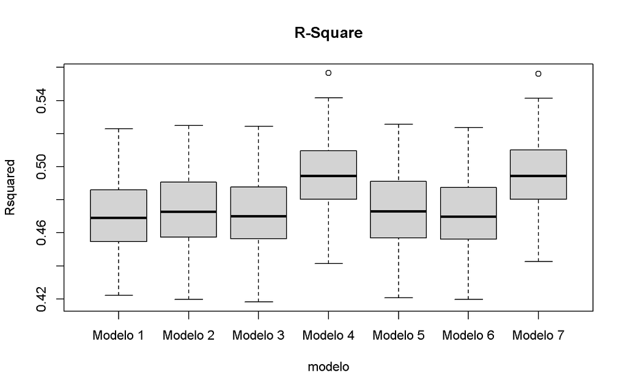

```r
## Pruebo los mejores de cada con validacion cruzada repetida
total<-c()
modelos<-sapply(list(modeloManual,modeloStepAIC,modeloStepBIC,modeloStepBIC_int,
                     modeloStepAIC_trans,modeloStepBIC_trans,modeloStepBIC_transInt),formula)
for (i in 1:length(modelos)){
  set.seed(1712)
  vcr<-train(as.formula(modelos[[i]]), data = data_train,
             method = "lm",
             trControl = trainControl(method="repeatedcv", number=5, repeats=20,
                                      returnResamp="all")
  )
  total<-rbind(total,cbind(vcr$resample[,1:2],modelo=rep(paste("Modelo",i),
                                                         nrow(vcr$resample))))
}
boxplot(Rsquared~modelo,data=total,main="R-Square")
```

```r
aggregate(Rsquared~modelo, data = total, mean) #el 4 y el 7 son mejores
```

```
##     modelo  Rsquared
## 1 Modelo 1 0.4699258
## 2 Modelo 2 0.4728659
## 3 Modelo 3 0.4711986
## 4 Modelo 4 0.4941896
## 5 Modelo 5 0.4732228
## 6 Modelo 6 0.4713260
## 7 Modelo 7 0.4942795
```

```r
aggregate(Rsquared~modelo, data = total, sd)
```

```
##     modelo   Rsquared
## 1 Modelo 1 0.02028599
## 2 Modelo 2 0.02089519
## 3 Modelo 3 0.02033126
## 4 Modelo 4 0.02100132
## 5 Modelo 5 0.02098290
## 6 Modelo 6 0.02019643
## 7 Modelo 7 0.02087643
```

```r
#vemos el número de parametros
length(coef(modeloStepBIC_int))
```

```
## [1] 29
```

```r
length(coef(modeloStepBIC_transInt))
```

```
## [1] 29
```

```r
# El primero tiene dos interacciones, el segundo una tranformación y azucar_tree

formula(modeloStepBIC_int)
```

```
## varObjCont ~ Clasificacion + Etiqueta + CalifProd_cont + Azucar_tree +
##     Acidez + Clasificacion:Etiqueta
```

```r
formula(modeloStepBIC_transInt)
```

```
## varObjCont ~ Clasificacion + Etiqueta + CalifProd_cont + Azucar_tree +
##     sqrxAcidez + Clasificacion:Etiqueta
```

## Esquema de selección aleatoria de variables

La idea que hay detrás de la selección aleatoria de variables, es la de someter a la función *step()* a muchas pruebas de robustez. Para ello, no es descabellado pensar que si le pedimos a step que trabaje con submuestras de los datos que contienen distintas observaciones cada vez, la selección de variables no estará condicionada por el conjunto de entrenamiento o no sobreajustará al mismo.

Lo que hacemos es repetir (de nuevo empirismo) el proceso clásico varias veces con distintos registros y evaluamos la estabilidad de los resultados. Parece lógico que si una selección de variables se mantiene inalterada en distintos conjuntos de observaciones, ese set de variables es robusto en capacidad de generalización.

Es tan simple como generar un bucle que repita el proceso *step()* con submuestras de datos, una vez generados se crea un dataframe de fórmulas y se cuenta cuantas veces aparece cada una. Se presenta una tabla de frecuencias para la valoración final.

La guardaremos en el objeto fr para poder acceder a las fórmulas más frecuentes posteriormente.

```r
## Seleccion aleatoria

rep<-20
prop<-0.7
modelosGenerados<-c()
for (i in 1:rep){
  set.seed(12345+i)
  subsample<-data_train[sample(1:nrow(data_train),prop*nrow(data_train),replace = T),]
  full<-lm(formIntT,data=subsample)
  null<-lm(varObjCont~1,data=subsample)
  modeloAux<-step(null,scope=list(lower=null,upper=full),direction="both",trace=0,k=log(nrow(subsample)))
  modelosGenerados<-c(modelosGenerados,paste(sort(unlist(strsplit(as.character(formula(modeloAux))[3]," [+] "))),collapse = "+"))
}
(freq(modelosGenerados,sort="dec")->fr)
```

```
##                                                                                                                                    n
## CalifProd_cont+Clasificacion+Clasificacion:CalifProd_cont+Clasificacion:Etiqueta+Etiqueta                                          3
## Azucar_tree+CalifProd_cont+Clasificacion+Clasificacion:Etiqueta+Etiqueta+sqrxAcidez                                                2
## Acidez+AcidoCitrico+Azucar_tree+CalifProd_cont+Clasificacion+Clasificacion:Etiqueta+Etiqueta                                       1
## Alcohol+Azucar_tree+CalifProd_cont+CalifProductor+Clasificacion+Clasificacion:Etiqueta+Etiqueta+sqrxAcidez                         1
## Alcohol+CalifProd_cont+Clasificacion+Clasificacion:CalifProd_cont+Clasificacion:Etiqueta+CloruroSodico+Etiqueta+sqrxAcidez         1
## Alcohol+CalifProd_cont+Clasificacion+Clasificacion:CalifProd_cont+Clasificacion:Etiqueta+CloruroSodico+Etiqueta+sqrxAcidez+sqrxpH  1
## Alcohol+CalifProd_cont+Clasificacion+Clasificacion:Etiqueta+Etiqueta                                                               1
## aleatorio2+Azucar_tree+CalifProd_cont+Clasificacion+Clasificacion:Etiqueta+Etiqueta+sqrxAcidez                                     1
## Azucar_tree+CalifProd_cont+Clasificacion+Clasificacion:CalifProd_cont+Clasificacion:Etiqueta+Etiqueta                              1
## Azucar_tree+CalifProd_cont+Clasificacion+Clasificacion:CalifProd_cont+Clasificacion:Etiqueta+Etiqueta+sqrxAcidez+sqrxCloruroSodico 1
## Azucar_tree+CalifProd_cont+Clasificacion+Clasificacion:Etiqueta+Etiqueta+logxaleatorio                                             1
## Azucar_tree+CalifProd_cont+Clasificacion+Clasificacion:Etiqueta+Etiqueta+pH+sqrxAcidez                                             1
## Azucar_tree+CalifProd_cont+Clasificacion+Clasificacion:Etiqueta+Etiqueta+Sulfatos                                                  1
## CalifProd_cont+Clasificacion+Clasificacion:CalifProd_cont+Clasificacion:Etiqueta+CloruroSodico+Etiqueta                            1
## CalifProd_cont+Clasificacion+Clasificacion:Etiqueta+CloruroSodico+Etiqueta+pH+sqrxAcidez                                           1
## CalifProd_cont+Clasificacion+Clasificacion:Etiqueta+Etiqueta                                                                       1
## CalifProd_cont+Clasificacion+Clasificacion:Etiqueta+Etiqueta+sqrxAcidez+sqrxpH                                                     1
##                                                                                                                                     %
## CalifProd_cont+Clasificacion+Clasificacion:CalifProd_cont+Clasificacion:Etiqueta+Etiqueta                                          15
## Azucar_tree+CalifProd_cont+Clasificacion+Clasificacion:Etiqueta+Etiqueta+sqrxAcidez                                                10
## Acidez+AcidoCitrico+Azucar_tree+CalifProd_cont+Clasificacion+Clasificacion:Etiqueta+Etiqueta                                        5
## Alcohol+Azucar_tree+CalifProd_cont+CalifProductor+Clasificacion+Clasificacion:Etiqueta+Etiqueta+sqrxAcidez                          5
## Alcohol+CalifProd_cont+Clasificacion+Clasificacion:CalifProd_cont+Clasificacion:Etiqueta+CloruroSodico+Etiqueta+sqrxAcidez          5
## Alcohol+CalifProd_cont+Clasificacion+Clasificacion:CalifProd_cont+Clasificacion:Etiqueta+CloruroSodico+Etiqueta+sqrxAcidez+sqrxpH   5
## Alcohol+CalifProd_cont+Clasificacion+Clasificacion:Etiqueta+Etiqueta                                                                5
## aleatorio2+Azucar_tree+CalifProd_cont+Clasificacion+Clasificacion:Etiqueta+Etiqueta+sqrxAcidez                                      5
## Azucar_tree+CalifProd_cont+Clasificacion+Clasificacion:CalifProd_cont+Clasificacion:Etiqueta+Etiqueta                               5
## Azucar_tree+CalifProd_cont+Clasificacion+Clasificacion:CalifProd_cont+Clasificacion:Etiqueta+Etiqueta+sqrxAcidez+sqrxCloruroSodico  5
## Azucar_tree+CalifProd_cont+Clasificacion+Clasificacion:Etiqueta+Etiqueta+logxaleatorio                                              5
## Azucar_tree+CalifProd_cont+Clasificacion+Clasificacion:Etiqueta+Etiqueta+pH+sqrxAcidez                                              5
## Azucar_tree+CalifProd_cont+Clasificacion+Clasificacion:Etiqueta+Etiqueta+Sulfatos                                                   5
## CalifProd_cont+Clasificacion+Clasificacion:CalifProd_cont+Clasificacion:Etiqueta+CloruroSodico+Etiqueta                             5
## CalifProd_cont+Clasificacion+Clasificacion:Etiqueta+CloruroSodico+Etiqueta+pH+sqrxAcidez                                            5
## CalifProd_cont+Clasificacion+Clasificacion:Etiqueta+Etiqueta                                                                        5
## CalifProd_cont+Clasificacion+Clasificacion:Etiqueta+Etiqueta+sqrxAcidez+sqrxpH                                                      5
```

[output cut: 18 more lines]

```r
# Guardo la tabla de frecuancias para luego seleccionar los más relevantes y probarlos
```

Podemos seleccionar los 3 mejores modelos por ejemplo y enfrentarlos en la comparación final.

# Esquema de selección de variables por Lasso

Lasso es en realidad un método de regresión en sí mismo, cuya particularidad reside en que la optimización por mínimos cuadrados/máxima verosimilitud se ve restringida por una condición que no existía en regresiones ordinarias. Esta condición aplica al sumatorio del valor de los parámetros del modelo, esta restricción hace que el método pueda ser considerado como un selector de variables directamente.

No es el objetivo entrar en el proceso matemático subyacente a esta técnica y nos conformaremos con aplicarla como posible método de selección de variables. Si conviene saber que Lasso maneja un parámetro lambda que es encargado de cuantificar el peso que la restricción sobre los parámetros debe tener para una solución con error de estimación controlado. De esta forma, el primer paso es buscar ese valor de lambda (usualmente el que se encuentra a 1 desviación típica de mínimo para penalizar lo suficiente pero no tanto como para que el error se dispare) y con el evaluar el modelo por validación cruzada.

La función *cv.glmnet()* permite hacer esta operación, si bien requiere del uso previo de la función *model.matrix()* que realiza una extensión de las variables nominales a *dummies* y deja el archivo como lo necesita este paquete.

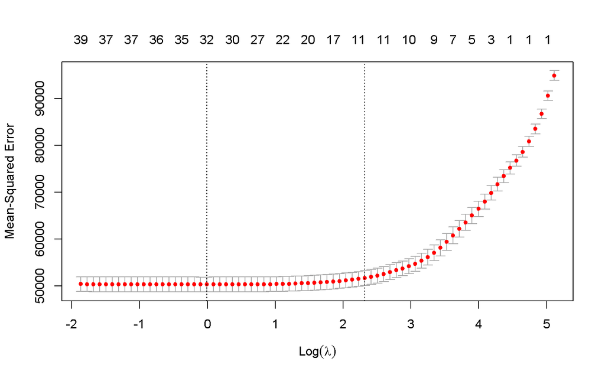

```r
## LASSO, lo hacemos sin interacciones pues, de lo contrario, puede coger interacciones y no las variables que las forman
y <- as.double(as.matrix(data_train[, 33]))
x<-model.matrix(varObjCont~., data=data_train)[,-1]#no cambiar el -1
set.seed(1712)
cv.lasso <- cv.glmnet(x,y,nfolds=5)
plot(cv.lasso)
```

Este es el comportamiento de lambda y el intervalo de 1se. Mostramos lo coeficiente.

```r
(betas<-coef(cv.lasso, s=cv.lasso$lambda.1se))
```

```
## 45 x 1 sparse Matrix of class "dgCMatrix"
##                                     1
## (Intercept)               534.0773034
## ID                          .
## Acidez                      .
## AcidoCitrico                .
## Azucar                      .
## CloruroSodico               .
## Densidad                    .
## pH                          .
## Sulfatos                    .
## Alcohol                     .
## EtiquetaM                 -87.4309835
## EtiquetaMB                 51.6486155
## EtiquetaMM               -130.6552110
## EtiquetaR                 -26.8780531
## CalifProductor2             .
## CalifProductor3             .
## CalifProductor4             .
## CalifProductor5-12        -29.9548476
## Clasificacion**           108.4966737
## Clasificacion***          211.3575091
## Clasificacion****         296.0263916
## ClasificacionDesconocido -222.2139289
## Region2                     .
## Region3                     .
## PrecioBotella               .
## CalifProd_cont            -20.5455398
## prop_missings               .
## aleatorio                   .
## aleatorio2                  .
## cuartaxID                   .
## sqrxAcidez                 -0.6480956
## expxAcidoCitrico            .
## logxAzucar                  .
## sqrxCloruroSodico           .
## xDensidad                   .
## sqrxpH                      .
## sqrtxSulfatos               .
## xAlcohol                    .
## xPrecioBotella              .
## xCalifProd_cont             .
## logxprop_missings           .
## logxaleatorio               .
## cuartaxaleatorio2           .
## Azucar_tree1.64-4.58        .
## Azucar_tree>4.58            .
```

Todos aquellos que aparecen con un . han sido descartados del modelo n base al cumplimiento de la restricción para ese valor de lambda que se suele considerar óptimo.

Por otra parte, al extenderse las nominales en dummies es posible que aparezcan efectos d niveles independientemente de la consideración de otros de la misma variable. Este es el caso de calificación de productor nominal en su categoría 5-12.

## Comparativa final y selección del modelo ganador

Finalmente vamos a considerar los modelos que parecen mejores en selección automática de variables “clásica”, aleatoria y lasso junto con el modelo manual de referencia y sencillo.

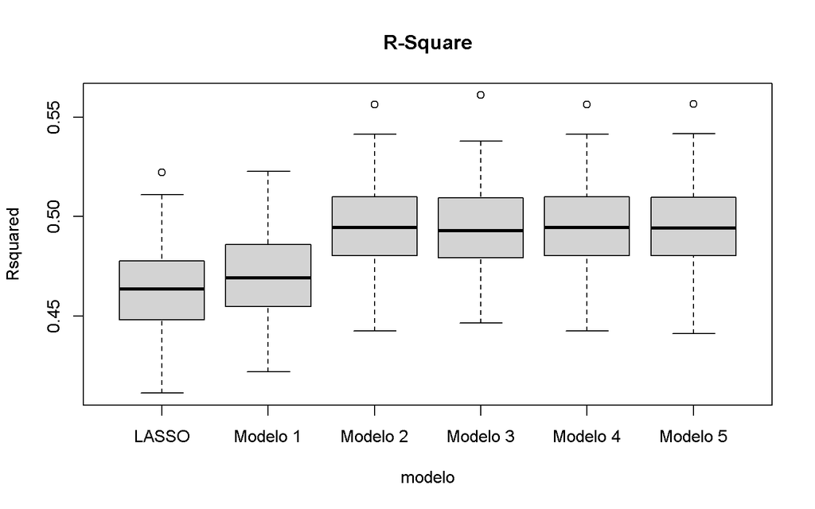

```r
## Comparación final, tomo el ganador de antes y los nuevos candidatos
total2<-c()
modelos2<-c(formula(modeloManual),formula(modeloStepBIC_transInt),
            as.formula(paste('varObjCont ~', rownames(fr)[1])),
            as.formula(paste('varObjCont ~', rownames(fr)[2])),
            as.formula(paste('varObjCont ~', rownames(fr)[3])))
for (i in 1:length(modelos2)){
  set.seed(1712)
  vcr<-train(as.formula(modelos2[[i]]), data = data_train,
             method = "lm",
             trControl = trainControl(method="repeatedcv", number=5, repeats=20,
                                      returnResamp="all")
  )
  total2<-rbind(total2,cbind(vcr$resample[,1:2],modelo=rep(paste("Modelo",i),
                                                         nrow(vcr$resample))))
}
set.seed(1712)
lassovcr <- train(varObjCont ~ ., data = data_train,
                  method = "glmnet",
                  tuneGrid=expand.grid(.alpha=1,.lambda=cv.lasso$lambda.1se),
                  trControl = trainControl(method="repeatedcv", number=5, repeats=20,
                                           returnResamp="all")
)
total2<-rbind(total2,cbind(lassovcr$resample[,1:2],modelo=rep("LASSO",
                                                         nrow(vcr$resample))))

boxplot(Rsquared~modelo,data=total2,main="R-Square") #el lasso funciona peor
```

```r
aggregate(Rsquared~modelo, data = total2, mean)
```

```
##     modelo  Rsquared
## 1    LASSO 0.4631262
## 2 Modelo 1 0.4699258
## 3 Modelo 2 0.4942795
## 4 Modelo 3 0.4939774
## 5 Modelo 4 0.4942795
## 6 Modelo 5 0.4939990
```

```r
aggregate(Rsquared~modelo, data = total2, sd)
```

```
##     modelo   Rsquared
## 1    LASSO 0.02100487
## 2 Modelo 1 0.02028599
## 3 Modelo 2 0.02087643
## 4 Modelo 3 0.02121515
## 5 Modelo 4 0.02087643
## 6 Modelo 5 0.02100519
```

```r
#Una vez decidido el mejor modelo, hay que evaluarlo (ver final del CódigoRegLineal)

#Este código se puede aplicar a regresión logística con pequeñas modificaciones (básicamente cambiar lm() por glm(),
#con la opción family=binomial) Para ello, ver código del pdf RegresiónLogísticaconR
```

En este punto tenemos un modelo manual generado en la práctica 2 que resultaba sencillo y no muy lejano en capacidad predictiva con respecto a otros mas complejos. En esta parte de selección de variables, todos los métodos excepto Lasso abogan por mantener la interacción de las variables clasificación y etiqueta con un ligera mejora de la capacidad predictiva pero, a su vez, un importante aumento en el número de parámetros.

En validación cruzada estamos en niveles de R2 iguales que los de los modelos complejos propuestos en la selección manual con lo que, en términos de mejora de la capacidad predictiva, los métodos de selección de variables no ha supuesto en este caso concreto una mejora sustancial.